# Quiz 05: Class

Complete this quiz in a .Rmd file. To turn in the quiz, push both a .Rmd file and a knitted .html file to your GitHub site.

Statement of Integrity: Copy and paste the following statement and then sign your name (by typing it) on the line below.

“All work presented is my own. I have not communicated with or worked with anyone else on this quiz.” Jessica Tom

Collaboration Reminder: You may not communicate with or work with anyone else on this quiz, but you may use any of our course materials or materials on the Internet.

Question 1 (7 points). Consider the following two bar plots using the palmerpenguins data set. The first is a plot of the penguin species while the second is a plot of the average bill length for each species.

```r
library(palmerpenguins)
library(tidyverse)
```

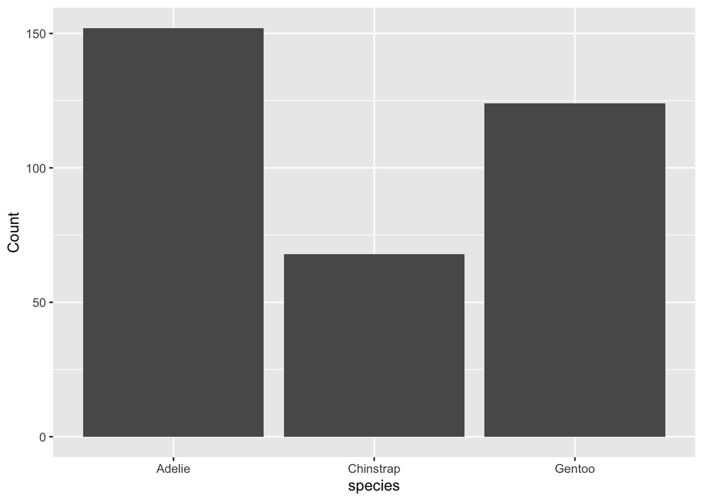

```r
ggplot(data = penguins, aes(x = species)) +
  geom_bar() +
  labs(y = "Count")
```

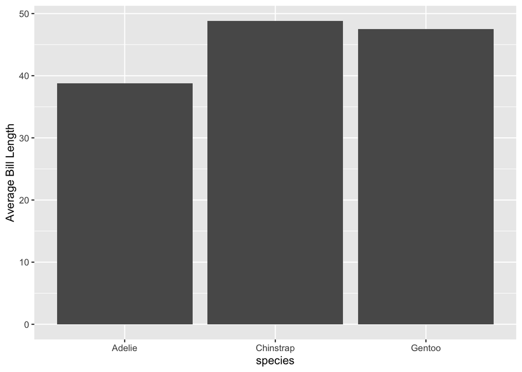

```r
ggplot(data = penguins %>% group_by(species) %>%
         summarise(avg_length = mean(bill_length_mm, na.rm = TRUE)),
       aes(x = species, y = avg_length)) +
  geom_col() +
  labs(y = "Average Bill Length")
```

Which of the two graphs is appropriate to construct? Give a one sentence reason.

The first graph of the count of the different species. The first bar graph is appropriate to construct because it does not require showing variability, as it only shows the number of penguins in each species, while the second graph is showing the bill length of the penguins, so it would be better to show the variability rather than the averages on a bar plot.

Question 2 (9 points). Use the Happy Planet Index data set to construct a graph that does not properly show variability in the underlying data. Recall that some variables in this data set are LifeExpectancy, Wellbeing, Footprint, and Region of the world.

```r
library(here)
hpi_df <- read_csv(here("data/hpi-tidy.csv"))
```

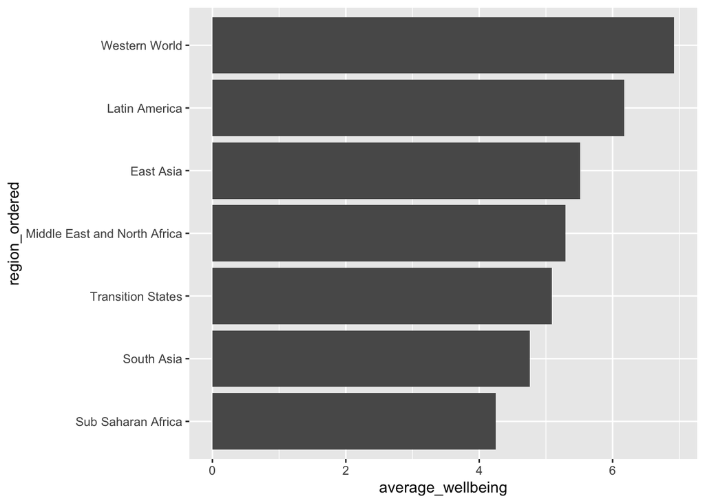

```r
hpi_average <- hpi_df %>% group_by(Region) %>%
  summarise(average_wellbeing = mean(Wellbeing)) %>%
  mutate(region_ordered = fct_reorder(.f = Region, .x = average_wellbeing))

ggplot(data = hpi_average, aes(x = region_ordered, y = average_wellbeing)) +
  geom_col() + coord_flip()
```

Question 3 (7 points). Fix your graph from the previous question so that it does properly show variability in the underlying data.

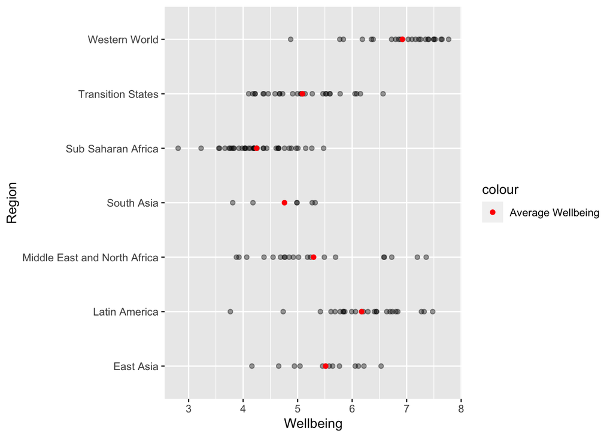

```r
ggplot(data = hpi_df, aes(x = Wellbeing, y = Region)) +
  geom_point(alpha = 0.4) +
  geom_point(data = hpi_average,
             aes(x = average_wellbeing, colour = "Average Wellbeing")) +
  scale_colour_manual(values = c("Average Wellbeing" = "red"))
```

The remaining 2 points are given for committing and pushing your .Rmd and .html files correctly to GitHub.